# VGK-Project2-AdvStats

### Data Set Information

The insurance.csv dataset contains 1338 observations and 7 attributes.

##### Context:

The data contains medical costs of people characterized by certain attributes. Let’s see if we can dive deep into this data to find some valuable insights.

Attributes:-

##### age:

age of primary beneficiary

##### sex:

insurance contractor gender, female, male

##### bmi:

Body mass index, providing an understanding of body, weights that are relatively high or low relative to height, objective index of body weight (kg / m ^ 2) using the ratio of height to weight, ideally 18.5 to 24.9

##### children:

Number of children covered by health insurance / Number of dependents

##### smoker:

Smoking

##### region:

the beneficiary's residential area in the US, northeast, southeast, southwest, northwest.

##### charges:

Individual medical costs billed by health insurance.

# 1. Import the necessary libraries

```python
# To enable plotting graphs in Jupyter notebook
%matplotlib inline
```

```python
# Numerical libraries
import numpy as np

# to handle data in form of rows and columns
import pandas as pd

# importing ploting libraries
import matplotlib.pyplot as plt

#importing seaborn for statistical plots
import seaborn as sns

#importing scipy stats
import scipy
import scipy.stats as st

from statsmodels.formula.api import ols      # For n-way ANOVA
from statsmodels.stats.anova import _get_covariance,anova_lm # For n-way ANOVA

#for 2 sample T-test
from scipy.stats import ttest_ind
```

# 2. Read the data as a data frame

```python
# reading the CSV file into pandas dataframe
ins_df = pd.read_csv("insurance.csv")
```

```python
# Check top few records to get a feel of the data structure
ins_df.head(10)
```

|  | age | sex | bmi | children | smoker | region | charges |
| --- | --- | --- | --- | --- | --- | --- | --- |
| 0 | 19 | female | 27.900 | 0 | yes | southwest | 16884.92400 |
| 1 | 18 | male | 33.770 | 1 | no | southeast | 1725.55230 |
| 2 | 28 | male | 33.000 | 3 | no | southeast | 4449.46200 |
| 3 | 33 | male | 22.705 | 0 | no | northwest | 21984.47061 |
| 4 | 32 | male | 28.880 | 0 | no | northwest | 3866.85520 |
| 5 | 31 | female | 25.740 | 0 | no | southeast | 3756.62160 |
| 6 | 46 | female | 33.440 | 1 | no | southeast | 8240.58960 |
| 7 | 37 | female | 27.740 | 3 | no | northwest | 7281.50560 |
| 8 | 37 | male | 29.830 | 2 | no | northeast | 6406.41070 |
| 9 | 60 | female | 25.840 | 0 | no | northwest | 28923.13692 |

```python
ins_df.count()
```

```
age         1338
sex         1338
bmi         1338
children    1338
smoker      1338
region      1338
charges     1338
dtype: int64
```

# 3. Perform basic EDA which should include the following and print out your insights at every step.

## a. Shape of the data

```python
ins_df.shape
```

```
(1338, 7)
```

#### Observations :: All 1338 rows and 7 columns seem to match the input data

## b. Data type of each attribute

```python
ins_df.dtypes
```

```
age           int64
sex          object
bmi         float64
children      int64
smoker       object
region       object
charges     float64
dtype: object
```

#### Observations :: We have age, bmi, children, charges as numbers. Sex, Smoker, Region are strings / categorical

## Categorical column Analysis

```python
ins_df.sex.value_counts()
```

```
male      676
female    662
Name: sex, dtype: int64
```

#### Observations :: Almost equally distributed male and female

```python
ins_df.smoker.value_counts()
```

```
no     1064
yes     274
Name: smoker, dtype: int64
```

```python
ins_df.region.value_counts()
```

```
southeast    364
southwest    325
northwest    325
northeast    324
Name: region, dtype: int64
```

#### Observations :: almost a balanced set of people from all 4 directions.. Slightly more people in south east.

## c. Checking the presence of missing values

```python
ins_df.isnull().values.any()
```

```
False
```

```python
ins_df.isna().values.any()
```

```
False
```

#### Observations :: I think we dont have any null / missing values. Cross checked by applying filter in excel. Looks like no null.

## d. 5 point summary of numerical attributes

```python
ins_df.describe().transpose()
```

|  | count | mean | std | min | 25% | 50% | 75% | max |
| --- | --- | --- | --- | --- | --- | --- | --- | --- |
| age | 1338.0 | 39.207025 | 14.049960 | 18.0000 | 27.00000 | 39.000 | 51.000000 | 64.00000 |
| bmi | 1338.0 | 30.663397 | 6.098187 | 15.9600 | 26.29625 | 30.400 | 34.693750 | 53.13000 |
| children | 1338.0 | 1.094918 | 1.205493 | 0.0000 | 0.00000 | 1.000 | 2.000000 | 5.00000 |
| charges | 1338.0 | 13270.422265 | 12110.011237 | 1121.8739 | 4740.28715 | 9382.033 | 16639.912515 | 63770.42801 |

#### Observations ::

Sd Deviation for Age, Charges seems large

## e. Distribution of ‘bmi’, ‘age’ and ‘charges’ columns.

#### bmi

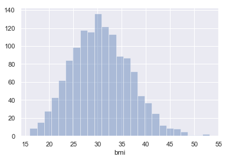

```python
sns.set(color_codes=True)
sns.distplot(ins_df['bmi'], kde = False)
```

#### Observations :: Lovely Normalish distribution.. Looks like real life data, peaking at 30 which borders on morbid obesity

#### age

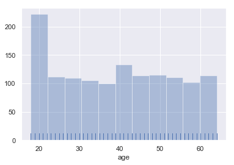

```python
sns.distplot(ins_df['age'], kde=False, rug=True)
```

#### Observations :: This is a bit wierd. Looks like we have double the number of people in their 20s than in other age ranges

#### charges

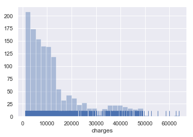

```python
sns.distplot(ins_df['charges'], kde=False, rug=True)
```

#### Observations :: Charges seem to be highly concentrated in the 1000 ~ 20000 range

## f. Measure of skewness of ‘bmi’, ‘age’ and ‘charges’ columns

```python
ins_df.skew()
```

```
age         0.055673
bmi         0.284047
children    0.938380
charges     1.515880
dtype: float64
```

#### Observations ::

Indications Age is least skewed slightly towards left tail of distribution BMI is moderately skewed with more values towards left tail of distribution Children is also highly skewed with more values towards left tail of distribution Charges highly skewed .. highest of the lot

## g. Checking the presence of outliers in ‘bmi’, ‘age’ and ‘charges' columns

#### age

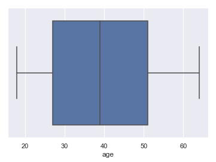

```python
sns.boxplot(ins_df['age'])
```

#### Observations :: No outliers in age

#### bmi

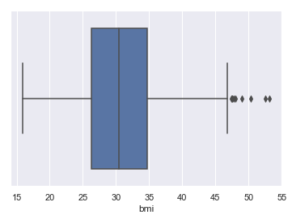

```python
sns.boxplot(ins_df['bmi'])
```

#### Observations :: Few outliers are discoevered beyond 46 or so. We may need to get rid of them if we make a model

#### charges

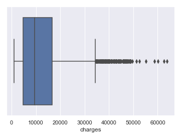

```python
sns.boxplot(ins_df['charges'])
```

#### Observations :: Large number of outliers.. As always insurance company is making a quick buck

## h. Distribution of categorical columns (include children)

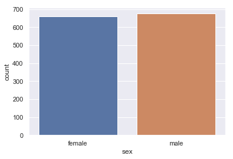

```python
sns.countplot(ins_df['sex'])
```

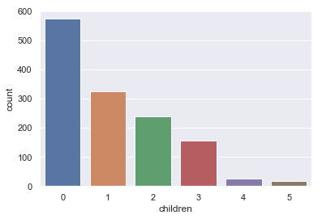

```python
sns.countplot(ins_df['children'])
```

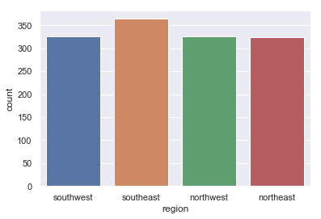

```python
sns.countplot(ins_df['region'])
```

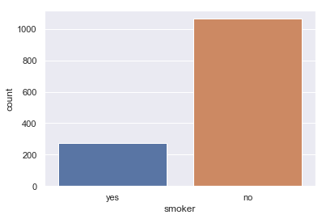

```python
sns.countplot(ins_df['smoker'])
```

#### Observations :: Almost balanced male female pop and well distributed across regions too. The number of people without kids is very high

## i. Pair plot that includes all the columns of the data frame

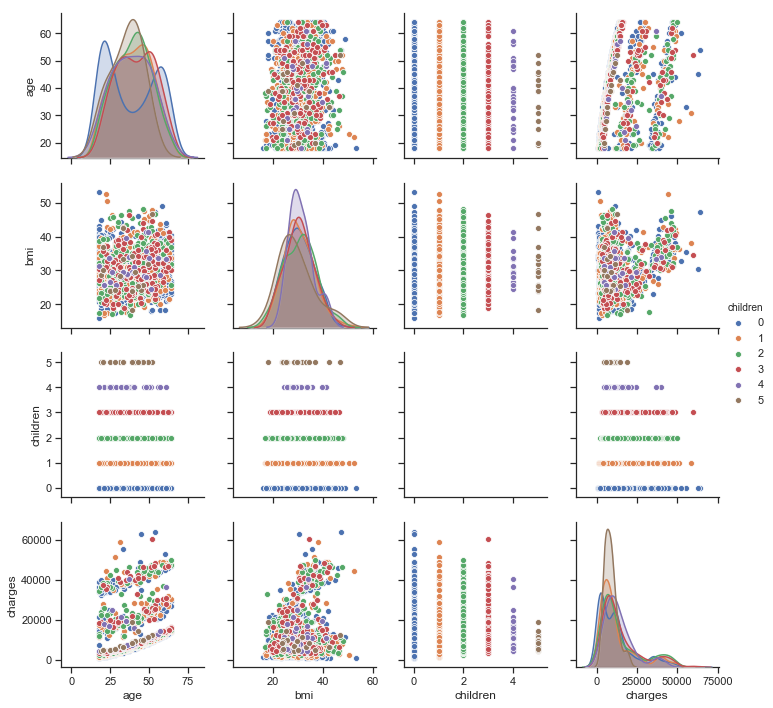

```python
sns.set(style="ticks")
sns.pairplot(ins_df, hue="children")
```

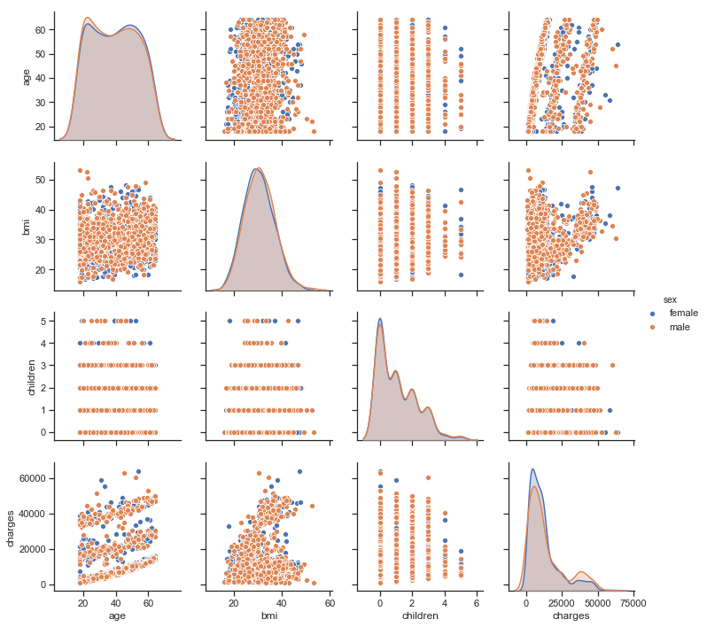

```python
sns.pairplot(ins_df, hue="sex")
```

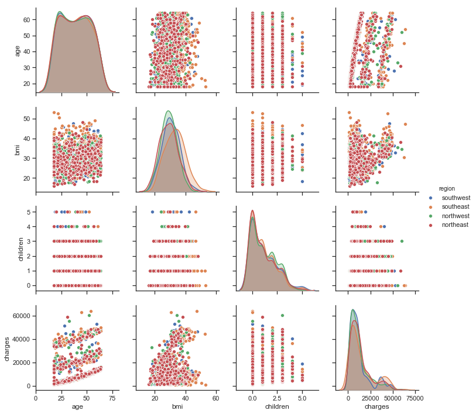

```python
sns.pairplot(ins_df, hue="region")
```

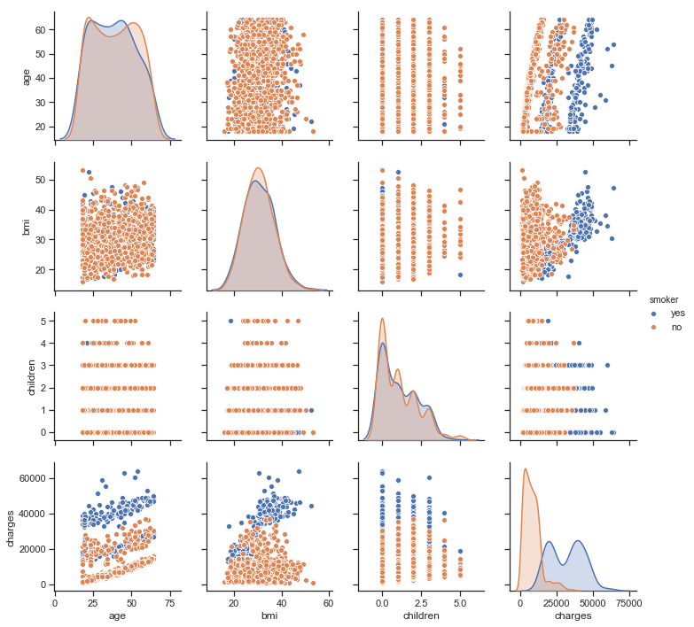

```python
sns.pairplot(ins_df, hue="smoker")
```

#### Observations :: Many interesting things here..

1. Smokers seem to be charged more insurance
2. As age increases, charges increase
3. BMI, Children does not seem to directly impact charge

# 4. Answer the following questions with statistical evidence

## a. Do charges of people who smoke differ significantly from the people who don't?

### NULL HYPOTHESIS

There is no impact of smoking on insurance charge

### ALT HYPOTHESIS

There is impact of smoking on insurance charge

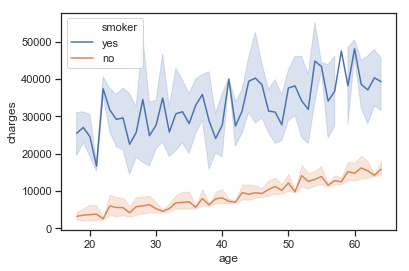

```python
sns.lineplot(x="age", y="charges", hue="smoker", data=ins_df);
```

#### Observations :: Yes .. from from graph we can see both age and smoking have incremental effect on charge

```python
#APPLY ANOVA

#Check impact on Charges vs categorical var smoker
formula_smoker = 'charges ~ C(smoker)'
model_smoker = ols(formula_smoker, ins_df).fit()
aov_table_smoker = anova_lm(model_smoker)
print(aov_table_smoker)
```

```
               df        sum_sq       mean_sq            F         PR(>F)
C(smoker)     1.0  1.215199e+11  1.215199e+11  2177.614868  8.271436e-283
Residual   1336.0  7.455432e+10  5.580413e+07          NaN            NaN
```

```python
#Trying Two Sample T-Test
# Tests whether the means of two independent samples are significantly different.

#Create 2 samples 1 smoker, 1 non - smoker
ins_df_smoker = ins_df.drop(ins_df[ins_df.smoker=='no'].index)
ins_df_nsmoker = ins_df.drop(ins_df[ins_df.smoker=='yes'].index)

print (ins_df_smoker.describe())
print (ins_df_nsmoker.describe())
```

```
              age         bmi    children       charges
count  274.000000  274.000000  274.000000    274.000000
mean    38.514599   30.708449    1.113139  32050.231832
std     13.923186    6.318644    1.157066  11541.547176
min     18.000000   17.195000    0.000000  12829.455100
25%     27.000000   26.083750    0.000000  20826.244213
50%     38.000000   30.447500    1.000000  34456.348450
75%     49.000000   35.200000    2.000000  41019.207275
max     64.000000   52.580000    5.000000  63770.428010
               age          bmi     children       charges
count  1064.000000  1064.000000  1064.000000   1064.000000
mean     39.385338    30.651795     1.090226   8434.268298
std      14.083410     6.043111     1.218136   5993.781819
min      18.000000    15.960000     0.000000   1121.873900
25%      26.750000    26.315000     0.000000   3986.438700
50%      40.000000    30.352500     1.000000   7345.405300
75%      52.000000    34.430000     2.000000  11362.887050
max      64.000000    53.130000     5.000000  36910.608030
```

```python
stat, pvalue = ttest_ind(ins_df_smoker['charges'] , ins_df_nsmoker['charges'])
print("Compare means", ins_df_smoker['charges'].mean() , ins_df_nsmoker['charges'].mean())
print("Tstatistic for charges, Pvalue", stat, pvalue)

if pvalue > 0.05:
	print('Samples are likely drawn from the same distributions (fail to reject H0)')
else:
	print('Samples are likely drawn from different distributions (reject H0)')
```

```
Compare means 32050.23183153285 8434.268297856199
Tstatistic for charges, Pvalue 46.664921172723716 8.271435842177219e-283
Samples are likely drawn from different distributions (reject H0)
```

# Conclusion 4a :: Since PR value <<< 0.05, we can say that NULL Hypothesis can be rejected. Also the HUGE F value(in ANOVA) indicates big dependency. Hence alternative hypothesis is right and there is impact of Smoking on insurance charge

## b. Does bmi of males differ significantly from that of females?

### NULL HYPOTHESIS

There is no variation in mean BMI for men vs female .

### ALT HYPOTHESIS

There is variation in mean BMI for men vs female .

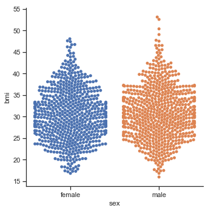

```python
sns.catplot(x='sex', y='bmi', data=ins_df, kind='swarm');
```

#### Observations :: No -- Does not look like from the graph. There are a few very high values for males.

```python
#APPLY ANOVA

#Check impact on BMI vs categorical var sex
formula_bmi_sex = 'bmi ~ C(sex)'
model_bmi_sex = ols(formula_bmi_sex, ins_df).fit()
aov_table_bmi_sex = anova_lm(model_bmi_sex)
print(aov_table_bmi_sex)
```

```
              df        sum_sq     mean_sq        F    PR(>F)
C(sex)       1.0    106.912532  106.912532  2.87897  0.089976
Residual  1336.0  49613.287854   37.135695      NaN       NaN
```

```python
#Trying Two Sample T-Test
# Tests whether the means of two independent samples are significantly different.

#Create 2 samples 1 make, 1 female
ins_df_m = ins_df.drop(ins_df[ins_df.sex=='female'].index)
ins_df_f = ins_df.drop(ins_df[ins_df.sex=='male'].index)

stat, pvalue = ttest_ind(ins_df_m['bmi'] , ins_df_f['bmi'])
print("Compare means", ins_df_m['bmi'].mean() , ins_df_f['bmi'].mean())
print("Tstatistic for bmi, Pvalue", stat, pvalue)

if pvalue > 0.05:
	print('Samples are likely drawn from the same distributions (fail to reject H0)')
else:
	print('Samples are likely drawn from different distributions (reject H0)')
```

```
Compare means 30.943128698224832 30.377749244713023
Tstatistic for bmi, Pvalue 1.696752635752224 0.08997637178984932
Samples are likely drawn from the same distributions (fail to reject H0)
```

# Conclusion 4b :: Since PR value > 0.05, we can say that NULL Hypothesis can't be rejected. Hence there is no impact on gender on mean bmi.

## c. Is the proportion of smokers significantly different in different genders?

### NULL HYPOTHESIS

There is no variation in proportion of smokers across genders. H0 : Proportion of women smoking = Proportion of men smoking

### ALT HYPOTHESIS

There is significant variation in proportion of smokers across genders. H1 : Proportion of women smoking <> Proportion of men smoking

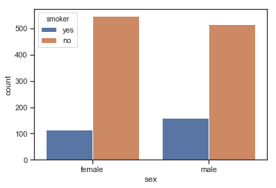

```python
sns.countplot(x="sex", hue="smoker", data=ins_df);
```

```python
# H0 :: female_smoker_proportion = male_smoker_proportion (hence two tail) p = 0.05
# H1 :: female_smoker_proportion != male_smoker_proportion

# REF :: https://www.statsmodels.org/dev/generated/statsmodels.stats.proportion.proportions_ztest.html

# we already have ins_df_m and ins_df_f - male female sub data sets
# WE will separate the smokers

ins_df_f_smoker = ins_df_f.drop(ins_df_f[ins_df_f.smoker=='no'].index)
ins_df_m_smoker = ins_df_m.drop(ins_df_m[ins_df_m.smoker=='no'].index)

#smoker_proportion_array = np.array([[ins_df_m.size,ins_df_m_smoker.size], [ins_df_f.size, ins_df_f_smoker.size]])
#summary = st.chi2_contingency (smoker_proportion_array)
#print("chi square summray for proportions of smokers across gender", summary)

from statsmodels.stats.proportion import proportions_ztest
count = np.array([ins_df_m_smoker.shape[0], ins_df_f_smoker.shape[0]])
print (count)
nobs = np.array([ins_df_m.shape[0], ins_df_f.shape[0]])
print (nobs)
stat, pvalue = proportions_ztest(count , nobs, alternative='two-sided')
#print("Compare means", ins_df_f_smoker.mean() , ins_df_f['bmi'].mean())
print("Tstatistic for proportions of smokers across gender, Pvalue", pvalue)

if pvalue > 0.05:
	print('Samples are likely drawn from the same distributions (fail to reject H0)')
else:
	print('Samples are likely drawn from different distributions (reject H0)')
```

```
[159 115]
[676 662]
Tstatistic for proportions of smokers across gender, Pvalue 0.005324114164320532
Samples are likely drawn from different distributions (reject H0)
```

# Conclusion 4c :: Since Pvalue < 0.05, we can say that NULL Hypothesis can be rejected. Hence there is significant variation in proportion of smokers across genders.

## d. Is the distribution of bmi across women with no children, one child and two children, the same ?

```python
#we already have female set from above
ins_df_f.head()
```

|  | age | sex | bmi | children | smoker | region | charges |
| --- | --- | --- | --- | --- | --- | --- | --- |
| 0 | 19 | female | 27.90 | 0 | yes | southwest | 16884.92400 |
| 5 | 31 | female | 25.74 | 0 | no | southeast | 3756.62160 |
| 6 | 46 | female | 33.44 | 1 | no | southeast | 8240.58960 |
| 7 | 37 | female | 27.74 | 3 | no | northwest | 7281.50560 |
| 9 | 60 | female | 25.84 | 0 | no | northwest | 28923.13692 |

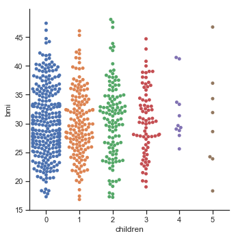

```python
sns.catplot(x='children', y='bmi', data=ins_df_f, kind='swarm');
```

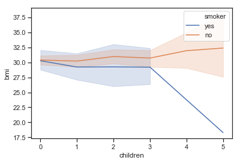

```python
sns.lineplot(x='children', y='bmi', hue='smoker', data=ins_df_f)
```

#### Observations :: Does not look like there is any significant difference in BMI vs Number of children for females 0,1,2 -- This is just by looking at it..

### NULL HYPOTHESIS

There is no impact of children (across women with no children, one child and two children) on Distribution of bmi. BAsically there is no variation in mean BMI for women with 0 ,1, 2 kids .

### ALT HYPOTHESIS

There is impact of children (across women with no children, one child and two children) on Distribution of bmi. BAsically there is variation in mean BMI for women with 0 ,1, 2 kids .

```python
#extract population of females with 0,1,2 children.

ins_df_f_012Children = ins_df_f.drop(ins_df_f[ins_df_f.children>=3].index)
ins_df_f_012Children.head(10)
```

|  | age | sex | bmi | children | smoker | region | charges |
| --- | --- | --- | --- | --- | --- | --- | --- |
| 0 | 19 | female | 27.900 | 0 | yes | southwest | 16884.92400 |
| 5 | 31 | female | 25.740 | 0 | no | southeast | 3756.62160 |
| 6 | 46 | female | 33.440 | 1 | no | southeast | 8240.58960 |
| 9 | 60 | female | 25.840 | 0 | no | northwest | 28923.13692 |
| 11 | 62 | female | 26.290 | 0 | yes | southeast | 27808.72510 |
| 13 | 56 | female | 39.820 | 0 | no | southeast | 11090.71780 |
| 16 | 52 | female | 30.780 | 1 | no | northeast | 10797.33620 |
| 20 | 60 | female | 36.005 | 0 | no | northeast | 13228.84695 |
| 21 | 30 | female | 32.400 | 1 | no | southwest | 4149.73600 |
| 23 | 34 | female | 31.920 | 1 | yes | northeast | 37701.87680 |

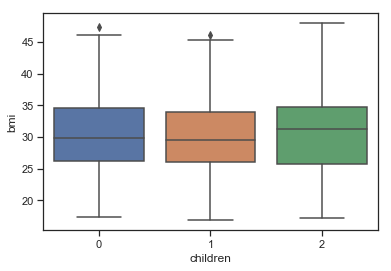

```python
#box plot the thing
sns.boxplot(x=ins_df_f_012Children['children'], y = ins_df_f_012Children['bmi'])
```

```python
#APPLY ANOVA

#Check impact on BMI vs categorical var children
formula = 'bmi ~ C(children)'
model = ols(formula, ins_df_f_012Children).fit()
aov_table = anova_lm(model)
print(aov_table)
```

```
                df        sum_sq    mean_sq         F    PR(>F)
C(children)    2.0     24.590123  12.295062  0.334472  0.715858
Residual     563.0  20695.661583  36.759612       NaN       NaN
```

# Conclusion 4d :: Since PR value > 0.05, we can say that NULL Hypothesis cant be rejected. Also F value is very small. Hence there is no impact on number of children on mean bmi.